# Assignment 4

## Preamble: Predicting competitor airfares on new routes

Air carriers regularly update their destination network and a necessary condition for adding a new flight connection to the existing network is that flights on this route are profitable. In addition to costs, profitability is determined by the price at which competitors could cater to the demand for flight transportation between two locations. A data-driven way of determining this would be on the basis of a supervised learning algorithm that has been trained on the fares for existing flight connections and which leverages information about route-specific characteristics. The dataset that we are using in this lab contains such information for more than 600 flight connections between different American cities. More specifically, we have information on the number of required stops, the market concentration on a particular route, Holiday destination status and a number of other characteristics that are detailed on [p.7 in the `mlba` library documentation](https://github.com/gedeck/mlba/blob/main/mlba_2.0.0.pdf). In the following, we will train and tune different supervised learning models that predict the average fare for a flight.

Before conducting the first part of this assignment, let’s load our data.

## Part one: Ridge regression with *glmnet*

*Glmnet* is the most popular library for ridge regression and the lasso in R. Its very comprehensible official documentation is available at https://rdrr.io/cran/glmnet/f/inst/doc/glmnet.pdf. In this basic part, you will familiarize yourself with the functionality of *glmnet*.

### Task 1a)

All functions that we will use in this lab require us to provide a matrix of pre-processed, quantitative inputs that can be directly put into a cost minimization problem. Provide that by conducting the following steps:

1. Use the `model.matrix()` command to create such a matrix,`X_1a`, of *all* predictors in `Airfares` (including a constant). In addition to the original predictors, also create interactions between every possible pair of (different) variables (use the shortcut for “all variables” `.` and square it). Then, remove the intercept column from `X_1a` since *glmnet* will automatically add a constant column for the intercept. Additionally, extract our outcome of interest from `Airfares` into a vector `y_1a`.
2. Use the `createDataPartition()` function in caret to create a vector `train_index` which contains the indexes of training data observations. Make sure that 70% of the data points in `Airfares` are used for model training.
3. Use `train_index` to split `X_1a` (`y_1a`) into training data `X_train_1a` (`y_train_1a`) and test data `X_test_1a` (`y_test_1a`).

```r
# # 1.
X_1a = model.matrix(FARE ~ .^2, data=Airfares)[,-1]
y_1a = Airfares$FARE
#
# # 2.
set.seed(5)
train_index <- createDataPartition(y_1a, p=0.7, list=FALSE)
#
# # 3.
X_train_1a = X_1a[train_index, ]
X_test_1a  = X_1a[-train_index, ]
#
y_train_1a = y_1a[train_index]
y_test_1a  = y_1a[-train_index]
```

### Task 1b)

The `glmnet()` command learns a regularized supervised learning model from inputs and output that you supply as function inputs. Furthermore, `glmnet()` is written as a command for the more general Elastic Net, so you always have to specify the desired value for the parameter $\alpha$. Now do the following:

1. Check the help file for `glmnet()` to figure out which argument(s) you have to set in order to activate/deactivate input standardization. Write your answer, as well as the default value of the argument(s) into the string variable `stdz_arguments_1b`.
2. Use `glmnet()` to learn ridge regression models for all tuning parameter values in `lambda_grid_1b` and save the learned model(s) as `ridge_fit_1b`. Input variables should be standardized by the command. Look up the `glmnet()` help file to figure out how to set the inputs to `glmnet()`.
3. Plot `ridge_fit_1b` with additional argument `xvar='lambda'` to get a regularization path for ridge regression.

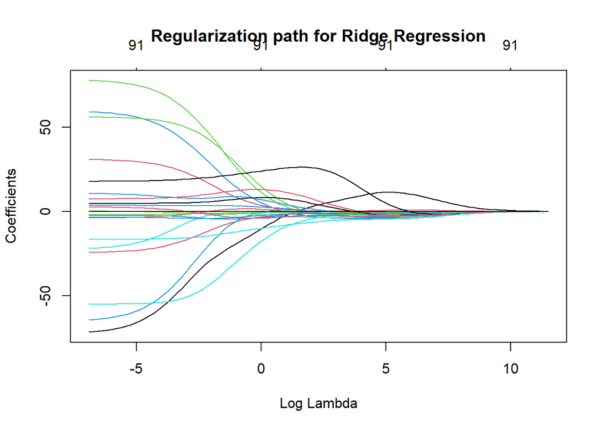

```r
# # 1.
stdz_arguments_1b <- "standardize = TRUE"
#
# # 2.
lambda_grid_1b <- 10^seq(5, -3, length.out = 100)
ridge_fit_1b  <- glmnet(X_train_1a, y_train_1a, alpha=0, lambda=lambda_grid_1b)
#
# # 3.
plot(ridge_fit_1b, xvar='lambda', main="Regularization path for Ridge Regression")
```

### Task 1c)

The *glmnet* library has a built-in procedure for k-fold cross-validation. It is called `cv.glmnet()`. Let’s explore this command now:

1. The syntax of `cv.glmnet` follows largely that of `glmnet`. So use the inputs that you specified to get `ridge_fit_1b` as inputs for `cv.glmnet`. Additionally, specify that you want to conduct 5-fold cross-validation with squared error as error function (it is rather sloppily referred to as *loss* in the `cv.glmnet()` help file) and use the grid of tuning parameter values `lambda_grid_1b`. Save your resulting object as `ridge_cv_1c`.
2. Plot `ridge_cv_1c`. You’ll see a smooth curve consisting of many red dots. However, there are also vertical grey bars around each of these dots. What do they indicate? Write your answer into the string variable `greybars_1c`. Additionally, there are two vertical, dotted lines. What do they indicate? Write your answer into the string variable `dottedlines_1c`

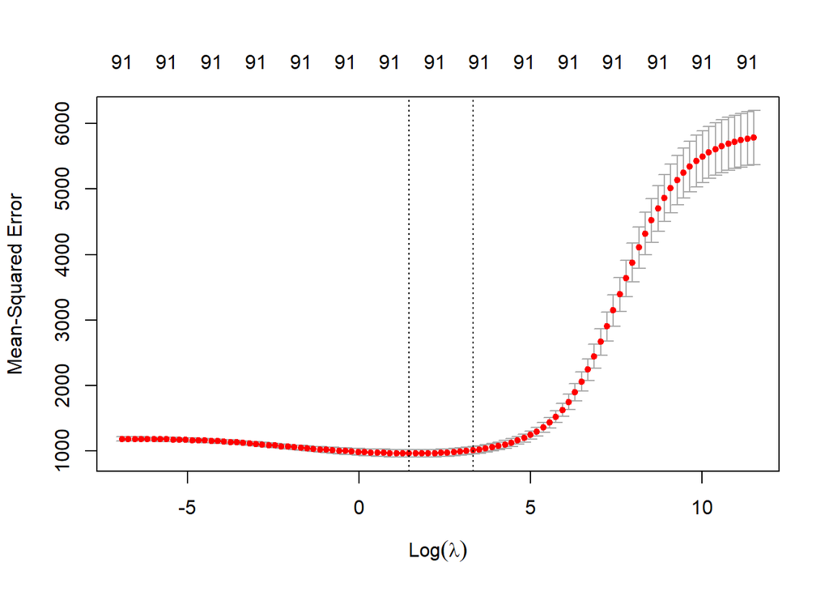

```r
# # 1.
set.seed(5)
ridge_cv_1c <- cv.glmnet(X_train_1a, y_train_1a, alpha=0, lambda=lambda_grid_1b, nfolds=5)
#
# # 2.
# ??
plot(ridge_cv_1c)
```

```r
greybars_1c    <- "Standard errors of the mean squared error at each lambda value."
dottedlines_1c <- "Left line: lambda with smallest mean CV error. Right line: largest lambda where error is within one standard error of the minimum."
```

### Task 1d)

The object `ridge_cv_1c` contains the tuning parameter value that minimizes cross-validation error. Extract this value into an object `ridge_lambda_best_1d`. Additionally, extract the one-S.E. choice for the tuning parameter into an object `ridge_lambda_1se_1d`. Lastly, judging from the regularization path from Task 1b, how much are the learned model coefficients shrunk to zero relative to a linear regression model without regularization? Save your answer as into the string variable `regularization_amount_1d`

```r
ridge_lambda_best_1d <- ridge_cv_1c$lambda.min
ridge_lambda_1se_1d <- ridge_cv_1c$lambda.1se
regularization_amount_1d <- "The coefficients in the ridge regression model are significantly shrunk towards zero compared to a linear regression model without regularization, especially as the lambda value increases."
```

### Task 1e)

If we want to get predictions from a learned model with particular tuning parameter, we do not need to run `glmnet()` again. Instead, we can get predictions straight from an existing `cv.glmnet()` object. The help file on `predict.cv.glmnet` tells you how.

Now get ridge regression predictions from `ridge_cv_1c` with the tuning parameter choice in `ridge_lambda_1se_1d` for the input combinations in `X_test_1a`. Save these predictions as `yhat_test_ridge_1e`

```r
yhat_test_ridge_1e <- predict(ridge_cv_1c, newx = X_test_1a, s = ridge_lambda_1se_1d, type = "response")
```

## Part 2: Lasso with *glmnet*

In this slightly more difficult section, we are going to repeat Part 1 for the lasso and improvise a little with the model specification.

### Task 2a)

Conduct the following steps:

1. Run `cv.glmnet()` with the same settings as in Task 1c (albeit for the lasso, not ridge regression) to determine the optimal value for $\lambda$. Save the resulting object as `lasso_cv_2a`.
2. Look at the plot of `lasso_cv_2a` and decide whether you want to pick the tuning parameter that minimizes cross-validation error or the value that results from the one-S.E. rule. State and motivate your choice in the string variable `bestlambda_lasso_2a`.
3. Use the learned lasso with the tuning parameter of your choice to predict test outcomes. Save your predictions as `yhat_test_lasso_2a`.

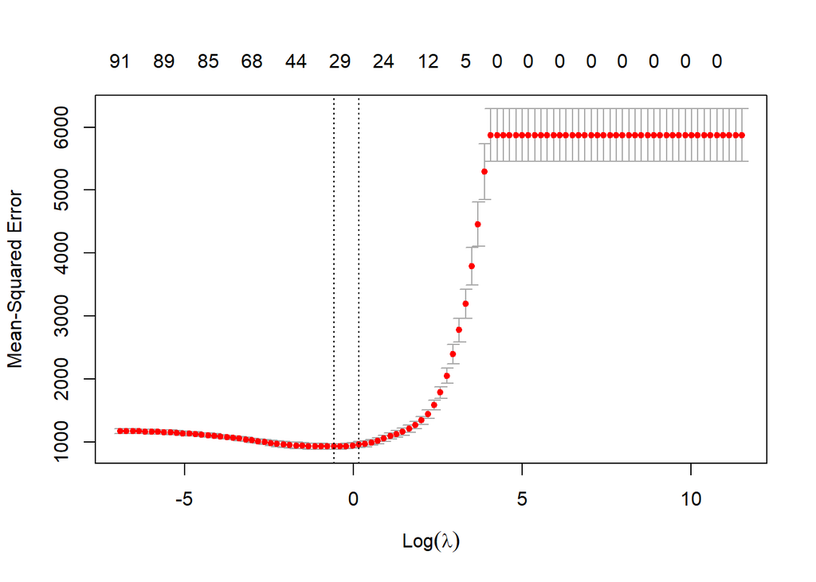

```r
# # 1.
set.seed(5)
lasso_cv_2a <- cv.glmnet(X_train_1a, y_train_1a, alpha=1, lambda=lambda_grid_1b, nfolds=5)
#
# # 2.
plot(lasso_cv_2a)
```

```r
bestlambda_lasso_2a <- "I chose the lambda value from the one-S.E. rule because it offers a more regularized (and possibly simpler) model within one standard error of the model with the minimum cross-validation error. This choice aims to prevent overfitting while maintaining decent prediction accuracy."
yhat_test_lasso_2a <- predict(lasso_cv_2a, newx = X_test_1a, s = lasso_cv_2a$lambda.1se, type = "response")
```

### Task 2b)

The performance of regularized linear regression models crucially depends on which input variables we use. We already exploited this fact by adding interactions between any two variables in `X_train_1a` to our model inputs. Now, we additionally use the principal components of the *original data* (without interactions) and therefore create a hybrid between regularization and dimension reduction. Conduct the following steps:

1. Use `preProcess()` to calculate the transformations that we need to obtain all 13 principal components of the data frame `X_train_2a` below. You can do that by specifying the correct pre-processing method. Save the transformations as `pca_param_2b`
2. “Predict” the principal component scores for `X` and save them as `X_pc_2b`
3. Combine the columns of `X_train_1a` and `X_pc_2b` into a matrix `Xplus_train_2b`

```r
X_2b = model.matrix(FARE ~ -1 + ., data=Airfares)[,-1]
X_train_2b =X_2b[train_index,]
#
pca_param_2b <- preProcess(X_train_2b, method = "pca", pcaComp = 13)
X_pc_2b <- predict(pca_param_2b, X_train_2b)
Xplus_train_2b <- cbind(X_train_1a, X_pc_2b)
```

### Task 2c)

Conduct the steps of Task 2a again, but now use your augmented input matrix `Xplus_train_2b` and don’t construct model predictions yet.

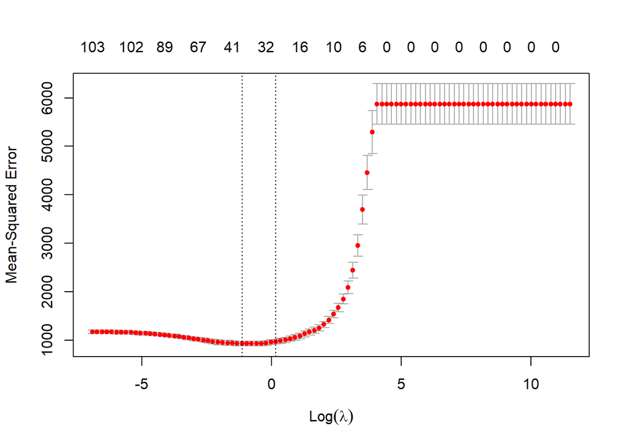

```r
set.seed(5)
lasso2_cv_2c <- cv.glmnet(Xplus_train_2b, y_train_1a, alpha=1, lambda=lambda_grid_1b, nfolds=5)
plot(lasso2_cv_2c)
```

```r
#
bestlambda_lasso2_2c <- "I chose the lambda value from the one-S.E. rule for the same reasons as before. It provides a balance between model complexity and prediction accuracy, potentially avoiding overfitting."
```

### Task 2d)

Before we can make output predictions from your chosen model, we need to augment our test data. First, use `pca_param_2b` to get principal component scores of `X_test_2e`. Save them as `Xpc_test_2d`. Then combine this matrix with `X_test_1e` into a matrix `Xplus_test_2d`. Finally, make output prediction for your augmented test inputs using `lasso2_cv_2c` and your preferred tuning parameter value. Save these predictions as `yhat_test_lasso2_2d`.

```r
X_test_2d <- X_2b[-train_index,]
Xpc_test_2d <- predict(pca_param_2b, X_test_2d)
Xplus_test_2d <- cbind(X_test_1a, Xpc_test_2d)
yhat_test_lasso2_2d <- predict(lasso2_cv_2c, newx = Xplus_test_2d, s = lasso2_cv_2c$lambda.1se, type = "response")
```

### Task 2e)

Lasso performs variable selection in addition to shrinkage. For this reason, we move outside our prediction-centered machine learning bubble for a second and have a look at the input variables that are included in our chosen lasso model from Task 2c. The `coef()` command allows us to extract model coefficients from an existing `cv.glmnet()` object. In order to get coefficients for a single tuning parameter, we define its value as a second function input `s`. Get the coefficient vector of the learned model that you used to make predictions in Task 2d and save it as `lasso2_coefs`.

```r
lasso2_coefs <- coef(lasso2_cv_2c, s = lasso2_cv_2c$lambda.1se)
print(lasso2_coefs)
```

```
## 105 x 1 sparse Matrix of class "dgCMatrix"
##                                 s1
## (Intercept)           7.411393e+01
## COUPON                1.049354e+01
## NEW                   .
## VACATIONYes           .
## SWYes                 .
## HI                    .
## S_INCOME              .
## E_INCOME              .
## S_POP                 .
## E_POP                 .
## SLOTFree              .
## GATEFree             -6.308530e+00
## DISTANCE              .
## PAX                   .
## COUPON:NEW            .
## COUPON:VACATIONYes    .
## COUPON:SWYes          .
## COUPON:HI             4.594295e-03
## COUPON:S_INCOME       2.206312e-04
## COUPON:E_INCOME       .
## COUPON:S_POP          .
## COUPON:E_POP          .
## COUPON:SLOTFree       .
## COUPON:GATEFree       .
## COUPON:DISTANCE       .
## COUPON:PAX            .
## NEW:VACATIONYes       .
## NEW:SWYes             .
## NEW:HI                .
## NEW:S_INCOME          .
## NEW:E_INCOME          .
## NEW:S_POP             .
## NEW:E_POP             .
## NEW:SLOTFree          .
## NEW:GATEFree         -2.505527e-01
## NEW:DISTANCE          .
## NEW:PAX               .
## VACATIONYes:SWYes     2.719554e+01
```

[output cut: 52 more lines]

```
## GATEFree:PAX          .
## DISTANCE:PAX          .
## PC1                  -3.275570e+00
## PC2                   .
## PC3                   .
## PC4                  -1.414615e+00
## PC5                   .
## PC6                   .
## PC7                   .
## PC8                   .
## PC9                   .
## PC10                  2.737518e-01
## PC11                  .
## PC12                  .
## PC13                 -4.353330e+15
```

## Part 3: Tuning elastic net with *caret*, performance evaluation

Elastic net is a bit inconvenient to implement in *glmnet* because the tuning parameter $\alpha$ cannot be chosen automatically with `cv.glmnet()`. This provides us with yet another opportunity to use the functionality of *caret* in this moderately difficult part.

### Task 3a)

Conduct the following tasks to prepare the inputs to`train()`:

1. Set the tuning controls and save them as `tunectrl_3a`. We want 5-fold cross-validation without repetition.
2. Generate a first grid of 400 values from 0 to 20 for $\lambda$ and save it as `lambda_seq_3a`.
3. Create a second grid of 6 values from 0 to 1 for $\alpha$ and save it as `alpha_seq_3a`.
4. Use `expand.grid()` to get all combinations of values in `lambda_seq_3a` and `alpha_seq_3a` and save the resulting data frame with variable names `lambda` and `alpha` as `tune_grid_elnet_3a`.

```r
# # 1.
tunectrl_3a <- trainControl(method = "cv", number = 5)
#
# # 2.
lambda_seq_3a <- seq(0, 20, length.out = 400)
#
# # 3.
alpha_seq_3a <- seq(0, 1, length.out = 6)
#
# # 4.
tune_grid_elnet_3a <- expand.grid(lambda = lambda_seq_3a, alpha = alpha_seq_3a)
```

### Task 3b)

Now we can tune our model and obtain test predictions:

1. Implement `train()` with `method="glmnet"`, tuning controls and tuning parameter grid from Task 4a and augmented inputs `Xplus_train_2b`. For consistency with the previous parts, let standardization be performed by `glmnet()` and not by `train()`. Save the resulting object as `tune_elnet_3b`
2. The tuning parameters chosen in step 1 are those that minimize CV error. Extract them into the object `tune_elnet_best_3b`. Does this choice result in a model that leans more into the direction of ridge regression or more towards the lasso? Write a well-motivated answer into the string variable `interpret_tune_3b`
3. Predict outputs from `tune_elnet_3b` for the test inputs `Xplus_test_2d`. Save these predictions as `yhat_test_elnet_3b`.

```r
# # 1.
set.seed(5)
tune_elnet_3b <- train(Xplus_train_2b, y_train_1a,
                       method = "glmnet",
                       trControl = tunectrl_3a,
                       tuneGrid = tune_grid_elnet_3a,
                       preProcess = NULL,
                       standardize = TRUE)
#
# # 2.
tune_elnet_best_3b <- tune_elnet_3b$bestTune
tune_elnet_best_3b
```

```
##      alpha    lambda
## 2006     1 0.2506266
```

```r
interpret_tune_3b  <- "The chosen model is a Lasso regression since the alpha value is 1."
yhat_test_elnet_3b <- predict(tune_elnet_3b, newdata = Xplus_test_2d)
```

### Task 3c)

We have now obtained predictions on test data for four different versions of the elastic net. It is time to find out which of them performs best. Use the observed test outcomes to calculate the mean squared error for all `yhat_test`-objects that we have created so far. Save them as `MSE_` plus the name of the method that we used previously.

Which one among the four candidate algorithms is superior? Write your conclusion and some details about the margin between the best and the remaining algorithms in the string variable `conclusion_3c`.

```r
MSE_ridge  <- mean((y_test_1a - yhat_test_ridge_1e)^2)
MSE_lasso  <- mean((y_test_1a - yhat_test_lasso_2a)^2)
MSE_lasso2 <- mean((y_test_1a - yhat_test_lasso2_2d)^2)
MSE_elnet  <- mean((y_test_1a - yhat_test_elnet_3b)^2)


mse_values <- c(MSE_ridge, MSE_lasso, MSE_lasso2, MSE_elnet)
names(mse_values) <- c("Ridge", "Lasso", "Lasso2", "Elnet")

margin <- sort(mse_values) - min(mse_values)

conclusion_3c <- paste("The superior method is Elastic Net, with margins of",
                       round(margin[2], 2), ",",
                       round(margin[3], 2), ",",
                       "and", round(margin[4], 2),
                       "for the next best methods respectively.")
conclusion_3c
```

```
## [1] "The superior method is Elastic Net, with margins of 34.91 , 40.02 , and 83.96 for the next best methods respectively."
```

## Part 4: Manual cross-validation for ridge regression

In this really advanced part, we are going to manually conduct the grid search over tuning parameter values that `cv.glmnet()` automatically provides us with when we fit the lasso or ridge regression. We are going to find the optimal tuning parameter for ridge regression since this allows us even to program the ridge regression estimator manually. The learning goal of this part is to realize what a gigantic mess machine learning life is without `caret` (or similar libraries).

### Task 4a)

Write a function `ridge_coefs_4a` that takes a matrix of input variables `X` an output vector `y` and a value of the tuning parameter `lam` as inputs and which returns the learned ridge regression coefficients. Use only matrix operations and basic R commands like `dim(x)`, `t()`, `solve()`, `rep()` or `diag()` inside the function.

```r
ridge_coefs_4a <- function(X, y, lam) {
  I <- diag(rep(1, ncol(X)))

  coefs <- solve(t(X) %*% X + lam * I) %*% t(X) %*% y

  return(coefs)
}
```

### Task 4b)

Write a function `scale_traintest_4b` that takes the following inputs:

- `Xtrain`: training inputs
- `ytrain`: training output
- `Xtest`: test inputs
- `ytest`: test outputs

The function is supposed to do the following:

1. Obtain mean and standard deviation of every column in `Xtrain` and standardize `Xtrain` (you may use `preProcess()`),
2. Standardize `Xtest` using the mean and standard deviation from step 1,
3. Get the mean of `ytrain` and demean `ytrain`,
4. Subtract the same mean from `ytest`.

`scale_traintest_4b` should then return a list object containing the transformed data.

```r
scale_traintest_4b <- function(Xtrain, ytrain, Xtest, ytest) {
  preprocess_params <- preProcess(Xtrain, method = c("center", "scale"))
  Xtrain_scaled <- predict(preprocess_params, Xtrain)
  Xtest_scaled <- predict(preprocess_params, Xtest)
  ymean <- mean(ytrain)
  ytrain_demeaned <- ytrain - ymean
  ytest_demeaned <- ytest - ymean
  return(list(Xtrain_scaled = Xtrain_scaled,
              ytrain_demeaned = ytrain_demeaned,
              Xtest_scaled = Xtest_scaled,
              ytest_demeaned = ytest_demeaned))
}
```

### Task 4c)

Write a function `ridge_testMSE_4c` that takes the following inputs:

- `Xtrain`: training inputs
- `ytrain`: training output
- `Xtest`: test inputs
- `ytest`: test outputs
- `lam`: tuning parameter value

The function is supposed to do the following: 1. Use `scale_traintest_4b` to get standardized inputs and demean outputs. 2. Get the ridge regression coefficients for given `lam` from the transformed training data using `ridge_coefs_4a`. 4. Predict output values on the transformed test data and calculate test MSE. This test MSE is returned as function output.

```r
ridge_testMSE_4c <- function(Xtrain, ytrain, Xtest, ytest, lam) {
  transformed_data <- scale_traintest_4b(Xtrain, ytrain, Xtest, ytest)
  Xtrain_transformed <- transformed_data$Xtrain_scaled
  ytrain_transformed <- transformed_data$ytrain_demeaned
  Xtest_transformed  <- transformed_data$Xtest_scaled
  ytest_transformed  <- transformed_data$ytest_demeaned
  coefs <- ridge_coefs_4a(Xtrain_transformed, ytrain_transformed, lam)
  yhat_test <- Xtest_transformed %*% coefs
  test_MSE <- mean((ytest_transformed - yhat_test)^2)
  return(test_MSE)
}
```

### Task 4d)

Write a function `ridge_testMSE_grid_4d` that takes the same inputs as `ridge_testMSE_4c` except that it takes an entire vector of tuning parameter values `lam_grid` instead of one value `lam`. For each value in `lam.grid` it gets test MSE from `ridge_testMSE_4c`. The entire vector of test MSEs is then returned as function output

```r
ridge_testMSE_grid_4d <- function(Xtrain, ytrain, Xtest, ytest, lam_grid) {
  test_MSEs <- sapply(lam_grid, function(lam) {
    ridge_testMSE_4c(Xtrain, ytrain, Xtest, ytest, lam)
  })

  return(test_MSEs)
}
```

### Task 4e)

Write a function `ridge_kfolderr_4e` that takes the following inputs:

- `X`: a matrix of model inputs,
- `y`: a vector of model outputs,
- `lamgrid:`a vector of tuning parameter values,
- `batchid`: A vector that specifies to which batch a particular data point belongs to.

`ridge_kfolderr_4e` should first identify $K$ as the maximum value in `batchid`. Then it should loop over the values $1,2,\ldots,K$. At iteration $k$, the loop should do the following:

1. Set `X_train` (`y_train`) as all data points in `X` (`y`) that do *not* belong to batch $k$,
2. Set `X_test` (`y_test`) as all data points in `X` (`y`) that *belong* to batch $k$.
3. Call `ridge_testMSE_grid_4c` for the given split into training and test batches to get test MSEs for the entire vector `lamgrid`.

Once the loop has finished, the test MSEs of all $K$ iterations should be averaged. The resulting vector of k-fold cross-validation errors should be the function output.

```r
ridge_kfolderr_4e <- function(X, y, lamgrid, batchid) {

  K <- max(batchid)
  mse_matrix <- matrix(0, nrow = K, ncol = length(lamgrid))

  # Loop over each fold
  for (k in 1:K) {
    # Define training and test sets
    train_indices <- which(batchid != k)
    test_indices  <- which(batchid == k)

    X_train <- X[train_indices, ]
    y_train <- y[train_indices]
    X_test  <- X[test_indices, ]
    y_test  <- y[test_indices]

    # Compute test MSE for each lambda
    mse_values <- ridge_testMSE_grid_4d(X_train, y_train, X_test, y_test, lamgrid)
    mse_matrix[k, ] <- mse_values
  }

  # Calculate the average test MSE for each lambda
  avg_mse <- colMeans(mse_matrix)

  return(avg_mse)
}
```

### Task 4f)

Below, I specify `lamgrid_4f`, a grid of potential values for $\lambda$, as well as `batches_4f`, an allocation of data points to batches. Do the following:

1. Use `ridge_kfolderr_4e` with these inputs as well as `y_train_1a` and `X_train_1a` to get k-fold CV errors for every tuning parameter value in `lamgrid_4f`. Save this object as `kfolderrs_4f`,
2. Use `which.min()` to extract the index of the smallest k-fold CV value in `kfolderrs_4f` into a new object `minindex_4f`,
3. Save the k-fold CV error at index `minindex_4f` of `lamgrid_4f` as `best_lambda_4f`.

```r
lamgrid_4f <- seq(5, 20, length=400)
set.seed(5)
batches_4f <- sample(rep(1:5, length.out=length(y_train_1a)))
#
kfolderrs_4f <- ridge_kfolderr_4e(X_train_1a, y_train_1a, lamgrid_4f, batches_4f)
minindex_4f <- which.min(kfolderrs_4f)
best_lambda_4f <- lamgrid_4f[minindex_4f]
```